# GLM Assignment 2

Joel Goodwin

2018-03-9

### Load Required Packages

```r
require(tidyverse)
```

### The Model Matrix

```r
#Create Predictor
predictor <- runif(5, min = 0, max = 1)

#Make a Model Matrix of Predictor values
model_matrix <- model.matrix(~predictor)

#View the created Model Matrix
print(model_matrix)
```

```
##   (Intercept)  predictor
## 1           1 0.52994230
## 2           1 0.59440666
## 3           1 0.86985629
## 4           1 0.13326636
## 5           1 0.04250644
## attr(,"assign")
## [1] 0 1
```

##### Set the Parameters for the Model

```r
B0 <- 10
B1 <- 2
parameters <- c(B0, B1)
print(parameters)
```

```
## [1] 10  2
```

##### Calaulate the Estimated Response Values

```r
response <- model_matrix %*% parameters
print(response)
```

```
##       [,1]
## 1 11.05988
## 2 11.18881
## 3 11.73971
## 4 10.26653
## 5 10.08501
```

##### Creating a Model Matrix with Factors

```r
as_factor <- factor(rep(c("low", "high"), 2))
model_matrix <- model.matrix(~as_factor)
print(model_matrix)
```

```
##   (Intercept) as_factorlow
## 1           1            1
## 2           1            0
## 3           1            1
## 4           1            0
## attr(,"assign")
## [1] 0 1
## attr(,"contrasts")
## attr(,"contrasts")$as_factor
## [1] "contr.treatment"
```

```r
B0 <- 5
B1 <- 5
parameters <- c(B0, B1)
response1 <- model_matrix %*% parameters
response2 <- B0 + B1 * (as.numeric(as_factor) - 1)
cbind(response1, response2)
```

```
##      response2
## 1 10        10
## 2  5         5
## 3 10        10
## 4  5         5
```

### The Poisson Model

In probability theory and statistics, the Poisson distribution is a discrete probability distribution that expresses the probability of a given number of events occurring in a fixed interval of time or space if these events occur with a known constant rate and independently of the time since the last event. The Poisson distribution can also be used for the number of events in other specified intervals such as distance, area or volume. Poisson distributions are especially useful for count data.  
Poisson distributions are defined by a single parameter, the poisson mean. There is no variance in poisson models because, by definition, the mean is equal to the variance in a poisson distribution. Therefore, what we really need are the poisson means for a set of levels of a factor that we are interested in.

```r
n.groups <- 3
n.sample <- 100
n <- n.groups * n.sample

x <- rep(1:n.groups, rep(n.sample, n.groups)) ## population indicator
population <- factor(x, labels = c("Pyrenees", "Massif Central", "Jura"))

length <- runif(n, 4.5, 7.0) ## wing length
length <- length - mean(length)
```

###### Create a Matrix for the Interaction between Length and Population

```r
Xmat <- model.matrix(~population * length)
beta.vector <- c(-2, 1, 2, 5, -2, -7)
```

Next use this matrix to create a poisson model

```r
linear_predictor <- Xmat[,] %*% beta.vector
lambda <- exp(linear_predictor)
# Lambda= poisson mean
C <- rpois(n = n, lambda = lambda)
```

Assess the fit of the model

```r
model1 <- glm(C ~ population * length, poisson)
summary(model1)
```

```
##
## Call:
## glm(formula = C ~ population * length, family = poisson)
##
## Deviance Residuals:
##     Min       1Q   Median       3Q      Max
## -2.9968  -0.7236  -0.2541   0.3405   2.9174
##
## Coefficients:
##                                 Estimate Std. Error z value Pr(>|z|)
## (Intercept)                      -2.6400     0.2322 -11.370  < 2e-16 ***
## populationMassif Central          1.9169     0.2933   6.536 6.33e-11 ***
## populationJura                    2.6269     0.2674   9.824  < 2e-16 ***
## length                            5.5895     0.2130  26.248  < 2e-16 ***
## populationMassif Central:length  -2.8789     0.2882  -9.989  < 2e-16 ***
## populationJura:length            -7.5195     0.2541 -29.598  < 2e-16 ***
## ---
## Signif. codes:  0 '***' 0.001 '**' 0.01 '*' 0.05 '.' 0.1 ' ' 1
##
## (Dispersion parameter for poisson family taken to be 1)
##
##     Null deviance: 3425.1  on 299  degrees of freedom
## Residual deviance:  258.3  on 294  degrees of freedom
## AIC: 774.84
##
## Number of Fisher Scoring iterations: 5
```

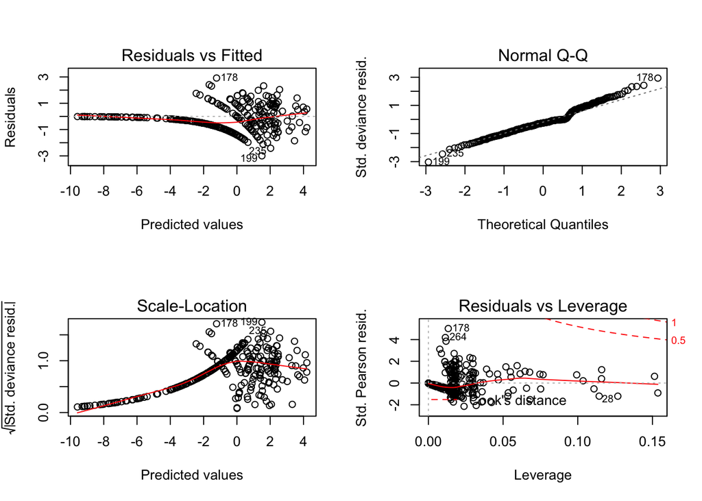

```r
par(mfrow=c(2, 2))
plot(model1)
```

###### What happens if we fit the model incorrectly?

By not specifying the distribution as poisson

```r
model2 <- glm(C ~ population*length)
summary(model2)
```

```
##
## Call:
## glm(formula = C ~ population * length)
##
## Deviance Residuals:
##     Min       1Q   Median       3Q      Max
## -13.400   -2.523   -0.409    1.595   49.615
##
## Coefficients:
##                                 Estimate Std. Error t value Pr(>|t|)
## (Intercept)                       5.9342     0.7558   7.851 7.74e-14 ***
## populationMassif Central         -3.9760     1.0611  -3.747 0.000215 ***
## populationJura                   -3.4383     1.0663  -3.224 0.001404 **
## length                           12.6350     0.9874  12.796  < 2e-16 ***
## populationMassif Central:length  -9.3168     1.4497  -6.427 5.25e-10 ***
## populationJura:length           -16.2664     1.3799 -11.788  < 2e-16 ***
## ---
## Signif. codes:  0 '***' 0.001 '**' 0.01 '*' 0.05 '.' 0.1 ' ' 1
##
## (Dispersion parameter for gaussian family taken to be 55.42997)
##
##     Null deviance: 28558  on 299  degrees of freedom
## Residual deviance: 16296  on 294  degrees of freedom
## AIC: 2063.8
##
## Number of Fisher Scoring iterations: 2
```

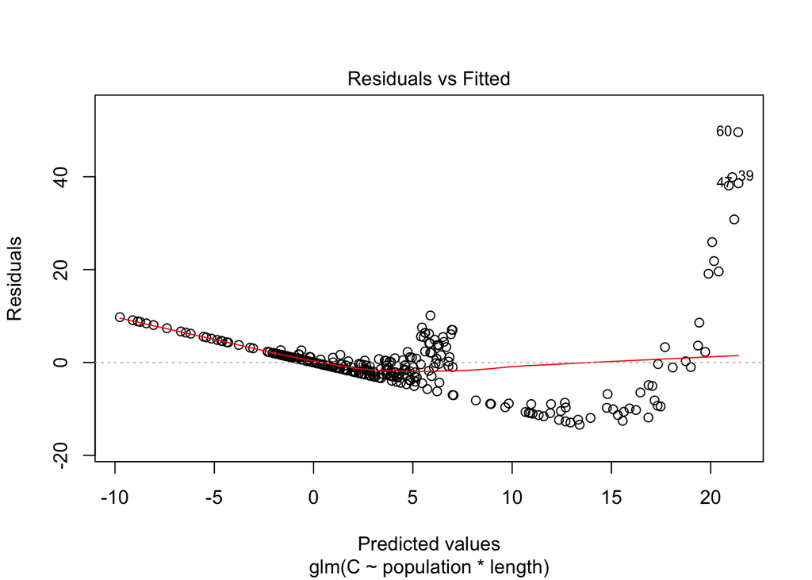

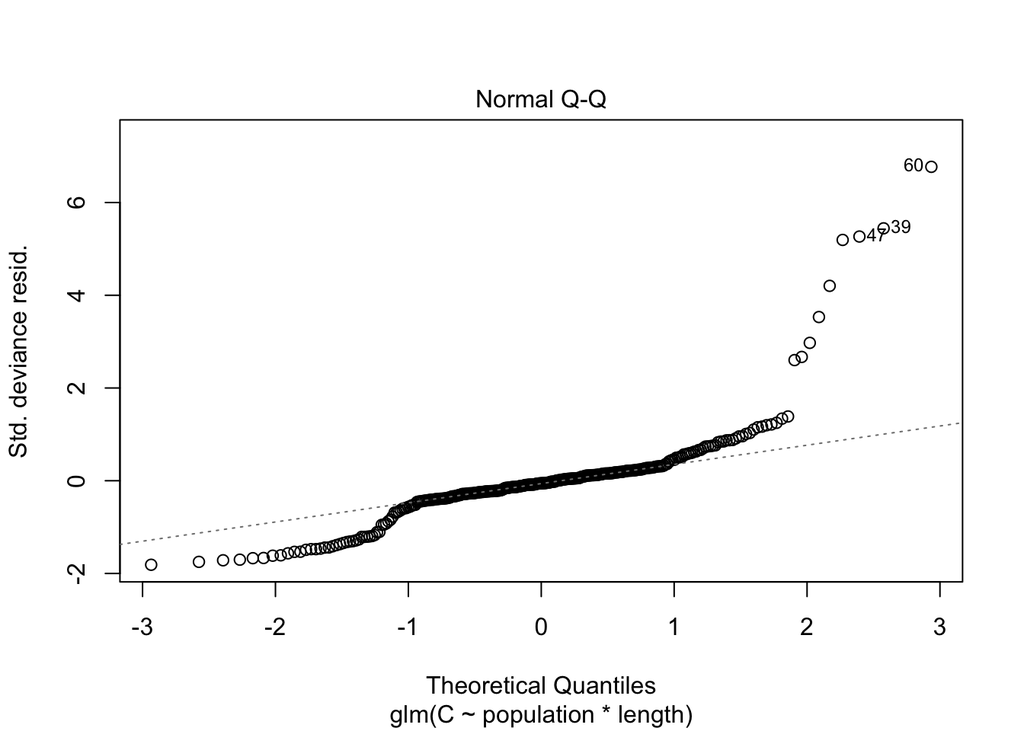

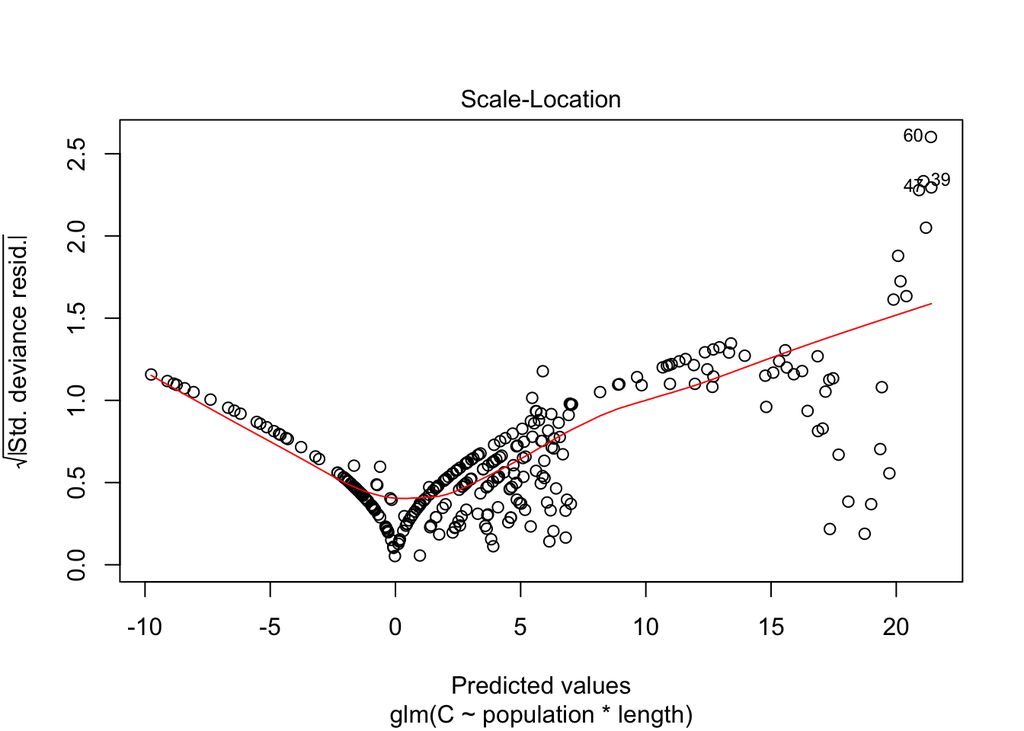

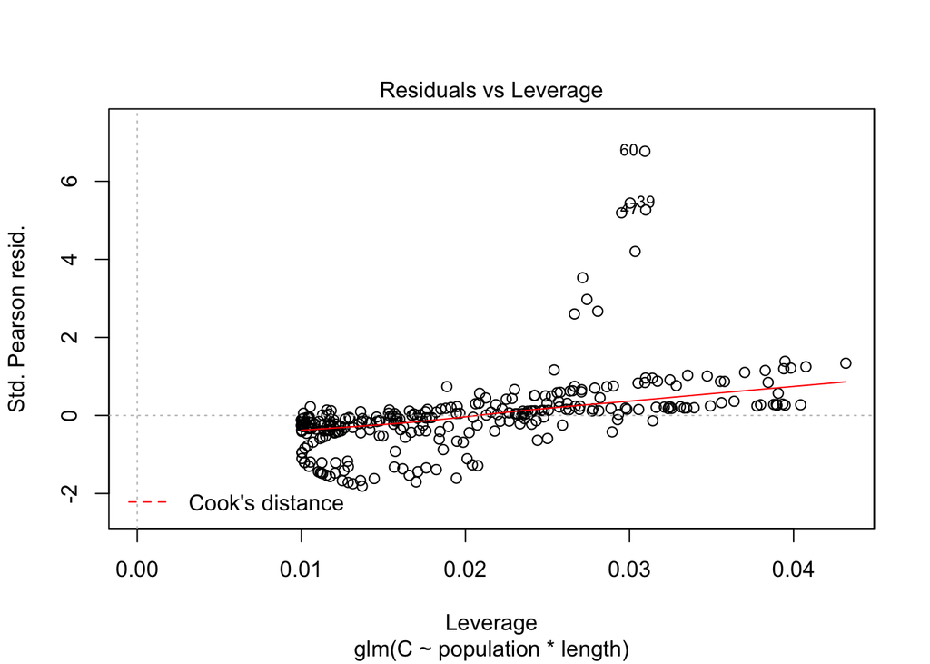

```r
plot(model2)
```

### The Binomial Model

The binomial distribution model is an important probability model that is used when there are two possible outcomes, commonly “success” and “failure” (hence “binomial”).  
The response for the below model is the proportion of a sample of snakes in a region that are black (there are two colour phases of the snake) and whether that relates to site wetness.

```r
n.groups <- 3
n.sample <- 100
n <- n.groups * n.sample

x <- rep(1:n.groups, rep(n.sample, n.groups))
population <- factor(x, labels = c("Pyrenees", "Massif Central", "Jura"))

wetness <- runif(n, 0, 1)
```

```r
N <- round(runif(n, 10, 50))
Xmat <- model.matrix(~population * wetness)
beta.vector <- c(-4, 1, 2, 6, 2, -5)
```

```r
linear.pred <- Xmat[,] %*% beta.vector
exp.p <- exp(linear.pred) / (1 + exp(linear.pred))
C <- rbinom(n = n, size = N, prob = exp.p)
```

Analyze the fit of this model

```r
model1 <- glm(cbind(C, N-C) ~ population*wetness, binomial)
summary(model1)
```

```
##
## Call:
## glm(formula = cbind(C, N - C) ~ population * wetness, family = binomial)
##
## Deviance Residuals:
##      Min        1Q    Median        3Q       Max
## -3.14480  -0.74342  -0.00841   0.69796   2.68390
##
## Coefficients:
##                                  Estimate Std. Error z value Pr(>|z|)
## (Intercept)                       -3.7817     0.1450 -26.074  < 2e-16 ***
## populationMassif Central           0.7646     0.1866   4.098 4.17e-05 ***
## populationJura                     1.8659     0.1745  10.693  < 2e-16 ***
## wetness                            5.8582     0.2178  26.900  < 2e-16 ***
## populationMassif Central:wetness   2.1909     0.3505   6.250 4.11e-10 ***
## populationJura:wetness            -4.9065     0.2701 -18.165  < 2e-16 ***
## ---
## Signif. codes:  0 '***' 0.001 '**' 0.01 '*' 0.05 '.' 0.1 ' ' 1
##
## (Dispersion parameter for binomial family taken to be 1)
##
##     Null deviance: 4169.78  on 299  degrees of freedom
## Residual deviance:  303.27  on 294  degrees of freedom
## AIC: 1188.6
##
## Number of Fisher Scoring iterations: 4
```

Analyze the fit of a wrongly-fitted model

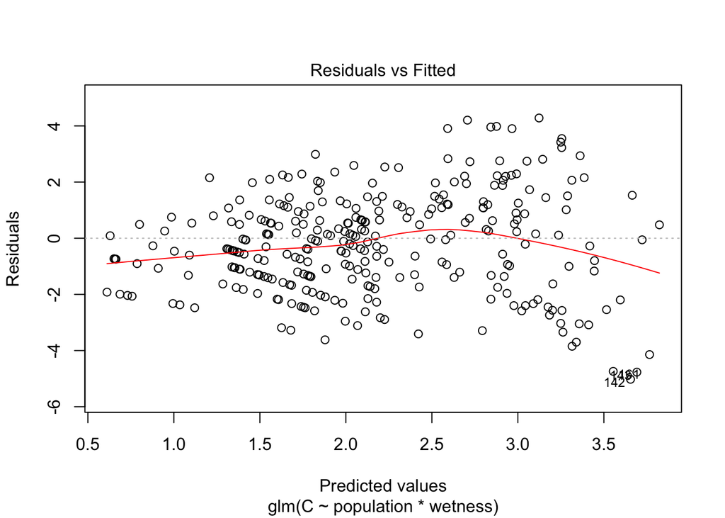

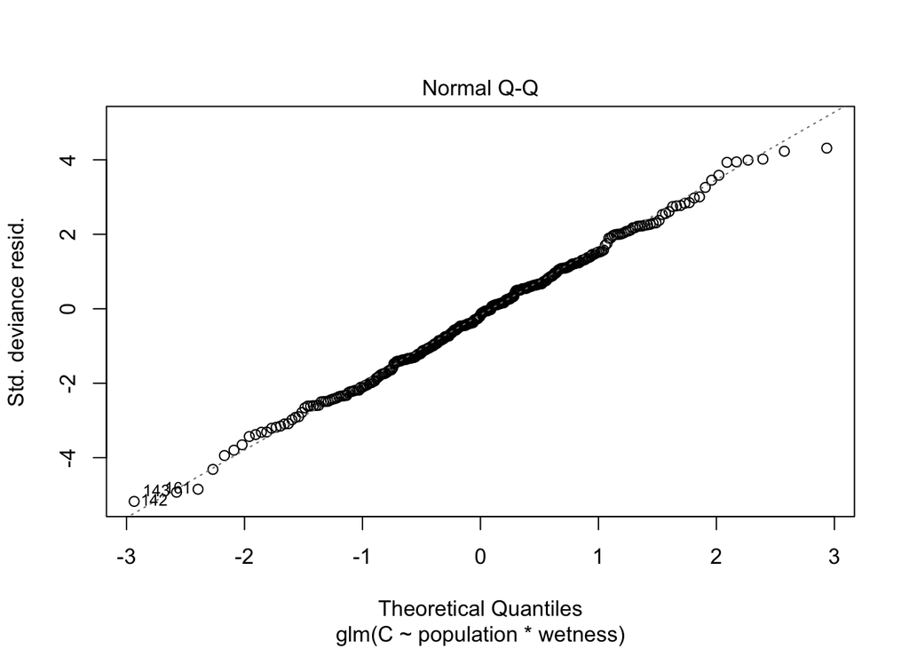

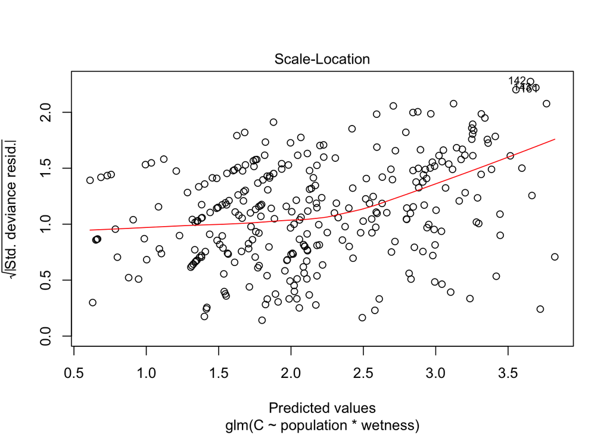

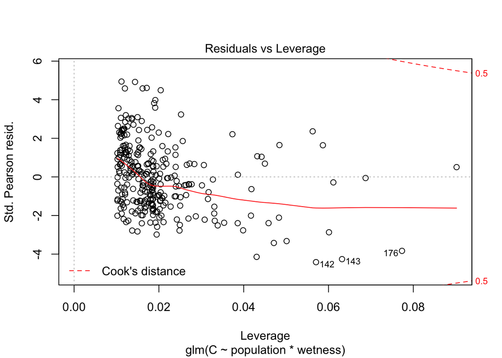

```r
model2 <- glm(C ~ population * wetness, poisson)
#(Incorrectly) specify a poisson distribution
plot(model2)
```